# Public Interest Data

2026-02-12

[figure not shown]

## Joins

Joins merge data sets based on key variables. The syntax is

- `name_join(x, y, by = "key")` if the key name matches
- `name_join(x, y, by = c("key_x" = "key_y))` if the key name doesn’t match
- `name_join(x,y, by = c("keyvar1", "keyvar2"))` if there are multiple keys
- `name_join(x,y)` will try to match on all common variables

Other behaviors

- If there are variable names in common that aren’t used in the join, they will be renamed `var.x` and `var.y`
- If observation in `x` match multiple values in `y`, the join will generate a 1:m match by default

## Join: Full, Inner

- `full_join()`: keeps all observations in x and y

[figure not shown]

- `inner_join()`: keeps only observations in both x and y

[figure not shown]

## Join: Left, Right

- `left_join()`: keeps all observations in x

[figure not shown]

- `right_join()`: keeps all observations in y

Animated visuals created by [Garrick Aden-Buie](https://github.com/gadenbuie/tidyexplain)

## Colors: Discrete

Color used to distinguish groups requires a qualitative color scale that is

- finite and unordered
- readily distinguished
- approximately equivalent

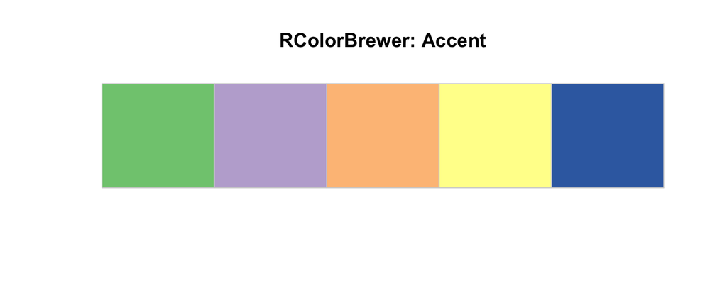

## Colors: Continuous

Color used to representing values or comparative magnitude requires a sequential color scheme that

- uses a many-valued gradient to distinguish larger/smaller values
- represets the distance between values
- may be single-hued, multi-hued, diverging

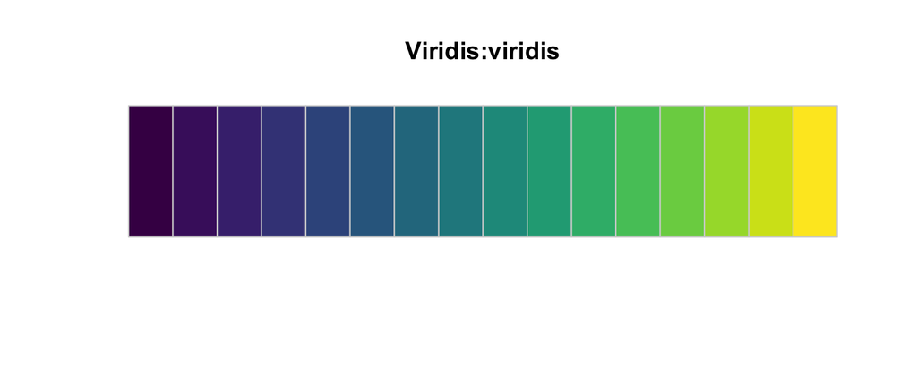

## Colors: Highlight

Color to highlight a group or threshold value requires accent colors that

- stands out/pops relative to the rest of the colors
- may be a single color against grey backdrop
- may be baed on intensity of colors in color scale

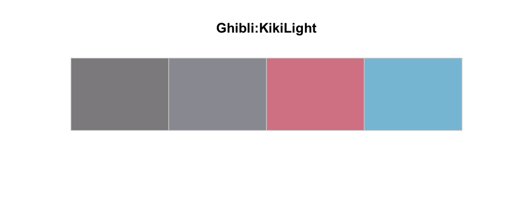

## Colors: Tips and Resources

Potential pitfalls

1. Encoding too much information (e.g., more than 5 to 8 groups)
   - Labeling points is an alternative
2. Coloring for the sake of coloring
   - And using oversaturated colors
3. Using non-monotonic scales for values (e.g., the rainbow scale)
4. Ignoring accessibility (e.g., color perception)

Emil Hvitfeldt’s color resources

- [Comprehensive list of color palettes in R!](https://github.com/EmilHvitfeldt/r-color-palettes)
- [paletteer package](https://cran.r-project.org/web/packages/paletteer/refman/paletteer.html)
- [paletteer on R Graph gallery](https://r-graph-gallery.com/package/paletteer.html)

## Let’s Play with R!

You know what to do…

[figure not shown]

Artwork by @allison_horst